# Tradeable jobs: does the argument add anything to Ricardo?

Working note: Venables (2018, 2020) and Rice and Venables (2023) rebuilt in R, tested against Ricardian benchmarks, and replicated on UK data

Author

Drafted by Claude Code (Claude Opus 5.5) for Dan Olner

Published

14 November 2026

## Summary

**The question.** Does the tradeable jobs argument add anything to plain Ricardian trade theory, or is it just a restatement of comparative advantage?

**How it was tested.**

- **Three versions of the argument:**
  - Venables (2020, with the 2018 paper’s fuller model), where “tradable” means internationally traded and subject to agglomeration;
  - Rice and Venables (2023), where tradability is a continuum of trade costs between places within Great Britain;
  - the policy shorthand: places prosper by having tradable jobs.
- **Two definitions of “plain Ricardian”:**
  - narrow: labour immobile between the places that trade (Ricardo, Dornbusch–Fischer–Samuelson, Eaton–Kortum);
  - broad: adds Ricardo inside a country, where labour moves and land doesn’t.
- **The work:** all four models are rebuilt in R and checked against the papers’ published numbers, then switched off one ingredient at a time. The UK evidence in Rice and Venables is replicated from open BRES, ASHE and input-output data.

Table 1: Verdicts: each version of the argument against each definition of plain Ricardian theory

| Version | Benchmark | Verdict | Why |
| --- | --- | --- | --- |
| V2020: tradable = internationally traded and clustered | Narrow (R0-R2) | Adds something | Its distinctive results (C1-C3 persistence, C6, the two fiscal regimes) need increasing returns with coordination failure, which R0-R2 lack. But its premise (C8) is Ricardo’s own, and the increasing-r… |
| V2020: tradable = internationally traded and clustered | Broad (with R3) | Adds something, narrowly | R3 already gives the price channel (C4), Dutch disease (C5) and the landowners’ gains (C14). What is left is lock-in from increasing returns, which works through city size and the national price of no… |
| RV2023: tradable = low trade costs within GB | Narrow (R0-R2) | Adds something | With immobile labour there is no sign reversal (C9) and revenue tracks physical productivity (C10). Both need mobile labour, which is R3. |
| RV2023: tradable = low trade costs within GB | Broad (with R3) | Mostly a restatement | RV2023 is an R3 model by construction (Ricardian a_is, no increasing returns). What it adds is a mapping from comparative advantage to nominal wages and measured productivity, plus a measurement metho… |
| Policy shorthand: places prosper by having tradable jobs | Narrow (R0-R2) | Nominal yes, real no | Tradable advantage raises nominal wages and measured productivity, but real income responds about equally to advantage in non-tradables. |
| Policy shorthand: places prosper by having tradable jobs | Broad (with R3) | Nominal yes, real no | Mobility equalises utility, so “prosperity” can only mean nominal wages, GVA per head or landowners’ wealth. A real-income version needs increasing returns or immobile people, which are claims about a… |

**What the argument adds, and what it doesn’t.**

- **Its central premise is Ricardo’s own.** Venables argues against “everywhere has a comparative advantage”. But Ricardo said comparative advantage governs trade between countries and not within them, because capital moves “from one province to another in the same country” (*Principles*, “On Foreign Trade”).
- **Its distinctive dynamics need increasing returns.** The range of equilibria, the lock-in after a shock, and the claim that a country can have too few tradable places all need localisation economies with coordination failure, as the trade literature has had since Graham (1923).
  - Switch agglomeration off in the rebuilt 2020 model and none of these survive: the set of equilibria collapses to a point, and a city that loses its tradable sector is replaced at once.
  - In the 2020 version, “tradeable jobs” could fairly be read as “jobs with increasing returns”.
- **Rice and Venables (2023) is a Ricardian model with land and mobile labour.** That is the broad benchmark itself. What it adds is the link from *where* comparative advantage lies to *nominal* wages and measured productivity:
  - a productivity advantage in tradables raises local nominal wages;
  - one in non-tradables can lower them.

  That sign reversal needs mobile labour; with immobile labour it disappears.
- **Tradable jobs don’t make places better off in real terms in any benchmark.**
  - With immobile labour, local real income responds about equally to productivity in tradables (0.32) and non-tradables (0.29).
  - With mobile labour, utility is equalised.
  - The real-income version of “places prosper through tradable jobs” needs increasing returns or people who can’t move. Those are claims about agglomeration and labour markets, not about tradability.
- **The UK evidence replicates closely but doesn’t identify tradability.**
  - Area earnings regressed on sparsity bias give R² 0.73, against 0.74 in the paper, with 65% of the effect through the area differential (paper 65%).
  - But sector sparsity correlates only 0.34 with the share of output actually exported. A measure of tradability built from exports adds nothing beside sparsity (t = -0.8).
  - Whatever sparsity picks up, it isn’t measured tradability.

**Problems found in the papers on the way.**

- **The agglomeration slopes don’t reproduce the figures.**
  - V2020’s appendix gives 0.015. The 2018 value, 0.15, reproduces the 2018 paper’s numbers.
  - The 2018 two-sector model’s stated 0.1 gives an equilibrium set a fraction of the size of its Figures 4 and 5; 0.3 matches.
- **C6 doesn’t hold at the papers’ own parameters.** With the papers’ linear agglomeration, *fewer* tradable cities raise aggregate real income (+1.45%), which is the 2018 paper’s own example. The “too few tradable places” loss appears only if agglomeration runs out at the margin.
- **Rice and Venables’s simulation draws** reproduce the published correlations only if the “variance 0.2” in the text is read as a standard deviation.
- **The skewness measure is a weak proxy even in their own model.** It is their main empirical measure, but its R² varies from about 0 to 0.3 between simulation runs.

## 1. What was tested

The plan, with the model equations and the full list of claims, is in tradeable_jobs_plan.md. Section 5 of the plan records the decisions:

- test both definitions of “plain Ricardian”;
- test all three versions of the argument;
- include the UK replication.

The models, all in `code/tradeable_jobs/`:

| Model | What it is | Rebuilt from |
| --- | --- | --- |
| A | One factor; cities make tradables (world price, localisation economies) or non-tradables (national price); mobile labour; linear city | Venables (2020); Venables (2018) section 2 |
| B | Two tradable sectors and the non-tradable, two skill types, Cobb-Douglas | Venables (2018) section 3 |
| C | Many places and sectors, Ricardian productivity by place and sector, Armington trade costs, land, Fréchet labour mobility | Rice and Venables (2023) sections 2–3 |
| D | Model C with switches (immobile labour, no land, equal trade costs, agglomeration), plus Dornbusch–Fischer–Samuelson | The benchmarks in plan part 3 |
| E | The UK test: 163 ITL3 areas, 251 SIC 3-digit sectors, 2015–2019 | Rice and Venables (2023) section 4 |

Two things about the papers shape everything below:

- **“Tradable” means different things.** In Venables (2018, 2020), non-tradables are traded freely *within* the country at a national price, and tradables are by assumption the only sectors with agglomeration economies. In Rice and Venables (2023), tradability is a trade cost between places, and there’s no agglomeration at all.
- **Everyone ends up with the same utility.** Every model assumes full employment and near-perfect mobility. So in all of them “left behind” means landowners, and (outside the models) people who can’t move.

## 2. The rebuilt models, and how well they match

### Model A: the 2020 model, and which slope Venables used

Table 2: Solving the 2020 model at the two published agglomeration slopes

| Source | Tmin (% of cities) | Tmax | Productivity gap at Tmin | Population ratio T:N | Rent ratio T:N | Real income, Tmin vs Tmax |
| --- | --- | --- | --- | --- | --- | --- |
| solved, slope 0.015 (2020 appendix) | 48.3 | 50.0 | 1.5% | 1.05 | 1.11 | 0.01% |
| solved, slope 0.15 (2018 appendix) | 28.9 | 50.0 | 23.3% | 2.00 | 4.00 | 1.45% |
| reported in Venables (2018), section 2 |  | 50.0 | 25.0% | 2.03 | 4.10 | 1.40% |

**Which slope.** The 2020 appendix’s 0.015 makes the set of equilibria almost vanish (48% to 50% of cities). The 2018 paper’s 0.15 reproduces what that paper reports. All results below use 0.15.

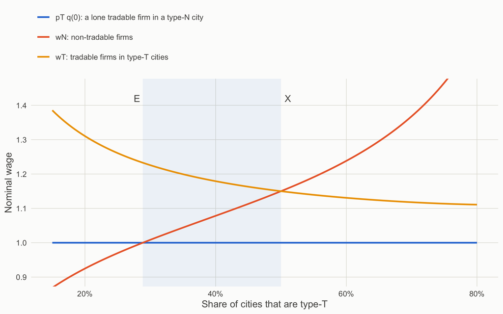

Figure 1: Model A: wages in each type of city as the share of tradable (type-T) cities varies. Any share between E and X is an equilibrium: type-N cities can’t attract a lone tradable firm (wN is above what it could pay, pT q(0)), and type-T cities pay more than non-tradable firms could.

**Checks against the 2018 paper’s statements** (`02_v2020_curves.R`). Five of the six hold. The exception is the statement that workers’ utility relative to rents falls “throughout the equilibrium range”. It holds from E up to 48.0% of cities, then dips slightly before X. Workers’ utility itself peaks inside the set, not at X.

**Shocks** (`03_v2020_shocks.R`). These reproduce the 2020 paper’s lists:

- **Import competition.** Hit cities switch to non-tradables, and every non-tradable city loses wages, people and rent. Remaining tradable cities grow and the rent share rises. A shock large enough to pass E brings in new tradables, which returns the economy to E.
- **An export boom in one sector.** It pushes old-sector cities into non-tradables once that sector’s price is 9% higher. Beyond about +12%, the remaining old-sector cities convert to the new sector instead: the “Seattle” route the paper mentions.
- **Fiscal contraction.** With the paper’s financing (a surplus sent abroad), regime 2 starts at G = -13.5. With a balanced budget, no city switches by G = −25. The two regimes depend on how the fiscal change is financed, which the paper doesn’t specify.

### Model B: the 2018 paper’s two-sector model

Table 3: Trade shock (pB/pA from 1 to 0.8), starting from S: rebuild against the paper

| Source | Type-A cities (%) | Type-B | Type-N | Rent, A | Rent, B | Rent, N | Total rent | Real income |
| --- | --- | --- | --- | --- | --- | --- | --- | --- |
| rebuild, slope 0.1 | 42.6 | 19.6 | 37.9 | 19% | -13% | -13% | 0.6% | 3.1% |
| rebuild, slope 0.3 | 33.3 | 23.0 | 43.7 | 71% | -28% | -28% | 4.7% | 4.8% |
| reported in Venables (2018) section 3.3 | 33.0 | 25.7 | 41.3 | 126% | -43% | -26% | 22.0% | 2.0% |

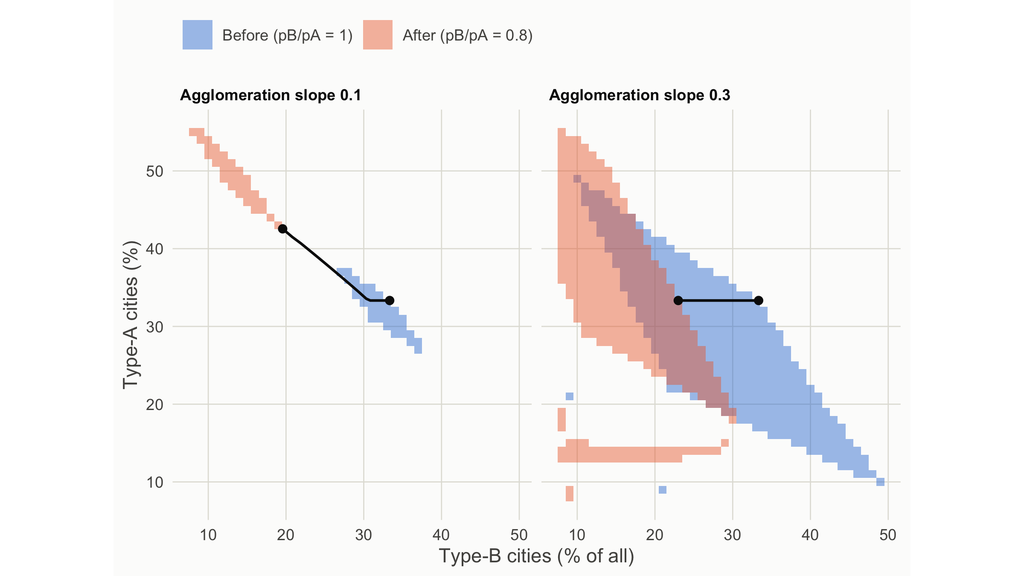

Figure 2: Model B: the equilibrium set (cells where no lone firm would gain by switching sector) before and after the trade shock, at the stated agglomeration slope (0.1) and at 0.3. The line is the path from S as pB/pA falls. With strong agglomeration the same city counts can have more than one solution for city sizes; each cell is solved from equal-sized cities.

**Equilibrium set.** At the stated slope, 0.1, the set is a small diamond around S (a third of cities of each type). A slope of 0.3 reproduces the extent of the paper’s Figures 4 and 5.

**The shock path.**

- **At slope 0.3** the path from S runs as the paper describes: horizontal, with type-B cities becoming type-N. The paper’s rent changes are larger than the rebuild’s.
- **At slope 0.1** the B cities switch to *A* instead. New tradables replace lost ones because the agglomeration advantage is too small to lock them out.

**One discrepancy I can’t resolve.** The paper’s mobility conditions (9) make w − r the same in every city type. On the exit-B boundary, that makes B and N cities identical in size and rent. The paper’s Figure 6 shows them different.

**What does match.** With coordination failure the skill premium rises less (1.33) than without (1.56), as section 3.3 says.

### Model C: Rice and Venables (2023)

The demand elasticities in Table 1 follow exactly from equation (11). Table 1 itself is only partly reproduced:

Table 4: Rice and Venables (2023) Table 1: place outcomes relative to the rest of the economy. Place i has a 50% productivity advantage in sector i; sector 1 is the most tradable, sector 9 the least.

| Source | Place | Wage | Rent | Employment | Own-sector share | CV of sector employment |
| --- | --- | --- | --- | --- | --- | --- |
| Reported in RV2023 Table 1 | 1 | 1.170 | 1.400 | 1.740 | 0.50 | 0.39 |
| Reported in RV2023 Table 1 | 5 | 1.060 | 1.270 | 1.550 |  | 0.26 |
| Reported in RV2023 Table 1 | 9 | 0.980 | 1.120 | 1.260 |  | 0.03 |
| Central reading (alpha 0.25, eta 1) | 1 | 1.192 | 1.279 | 1.430 | 0.51 | 1.39 |
| Central reading (alpha 0.25, eta 1) | 5 | 1.068 | 1.224 | 1.425 | 0.39 | 0.96 |
| Central reading (alpha 0.25, eta 1) | 9 | 0.986 | 1.125 | 1.280 | 0.14 | 0.09 |
| Land elasticity 2 | 1 | 1.174 | 1.247 | 1.715 | 0.50 | 1.35 |
| Land elasticity 2 | 5 | 1.055 | 1.204 | 1.676 | 0.38 | 0.95 |
| Land elasticity 2 | 9 | 0.978 | 1.115 | 1.411 | 0.14 | 0.10 |

**Which parts match.**

- **Wages match closely**, under every reading of the parameters.
- **Place 1’s population and rent come out lower** at the stated parameters. A land elasticity of 2 matches the wages and place 1’s population, but not the rest.
- **The table’s coefficient of variation looks wrong.** Its own footnote says half of place 1’s workers are in sector 1, as in the rebuild. Any standard coefficient of variation across nine sectors is then above 1.2, not 0.39.

**Comparative statics.** Equation (13) agrees with finite differences of the full model in sign and roughly in size: 0.20 against 0.18 for the most tradable sector, and −0.046 against −0.042 for the least.

Table 5: Rice and Venables (2023) Table 2a: area wages regressed on sparsity bias, mean of 20 simulation runs

| Source | Case | R², SD measure | R², skewness measure | Wage range (points) | cor(t_s, SD_s) | cor(t_s, SK_s) |
| --- | --- | --- | --- | --- | --- | --- |
| Paper | Shocks the same size in every sector (cols 1-2) | 0.45 | 0.17 | 21.7 | -0.958 | -0.908 |
| Paper | Shocks divided by t_s (cols 3-4) | 0.83 | 0.29 | 22.9 |  |  |
| Rebuild | Shocks divided by t_s (cols 3-4) | 0.75 | 0.06 | 22.7 | -0.930 | -0.882 |
| Rebuild | Shocks the same size in every sector (cols 1-2) | 0.34 | 0.06 | 21.4 | -0.958 | -0.897 |

**What the simulations show.** The wage range and the correlations between trade costs and sparsity match the paper. The R² for the skewness measure is lower on average. Run to run, it ranges from about 0 to 0.3, so the measure the paper uses on UK data is the noisier tradability proxy in its own model.

## 3. Which ingredient each claim needs

### Agglomeration does the work in the 2020 model

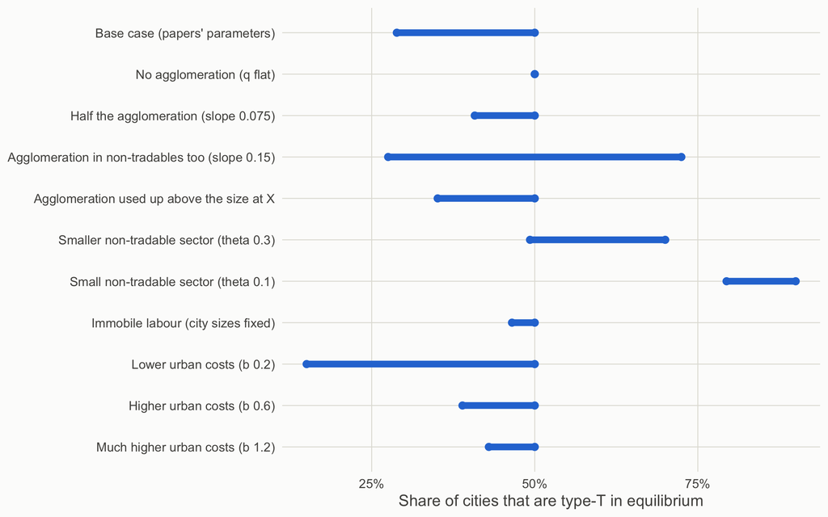

Figure 3: Model A: the range of equilibria (E to X, share of type-T cities) as ingredients are switched off or changed. A single point means one equilibrium: lost tradable cities are replaced at once.

Table 6: Model A: which claims survive each change (import shock of 5 cities from X; real income at E against X)

| Variant | Set width (points) | Lost cities replaced (of 5) | Type-N wage change | Hit-city utility gap | Real income, E vs X |
| --- | --- | --- | --- | --- | --- |
| Base case (papers’ parameters) | 21.1 | 0.0 | -3.2% | 0.0% | 1.45% |
| No agglomeration (q flat) | 0.0 | 5.0 | 0.0% | 0.0% | 0.00% |
| Half the agglomeration (slope 0.075) | 9.2 | 0.0 | -3.8% | 0.0% | 0.25% |
| Agglomeration in non-tradables too (slope 0.15) | 44.9 | 0.0 | -5.3% | 0.0% | 0.00% |
| Agglomeration used up above the size at X | 14.9 | 0.0 | -4.3% | 0.0% | -1.21% |
| Smaller non-tradable sector (theta 0.3) | 20.7 | 0.0 | -3.9% | 0.0% | 1.37% |
| Small non-tradable sector (theta 0.1) | 10.6 | 0.0 | -7.9% | 0.0% | 0.65% |
| Immobile labour (city sizes fixed) | 3.5 | 1.5 | -13.0% | -17.6% | -0.28% |
| Lower urban costs (b 0.2) | 35.0 | 0.0 | -1.9% | 0.0% | 4.56% |
| Higher urban costs (b 0.6) | 11.1 | 0.0 | -6.1% | 0.0% | 0.35% |
| Much higher urban costs (b 1.2) | 7.0 | 0.0 | -9.4% | 0.0% | -0.07% |

### The benchmarks

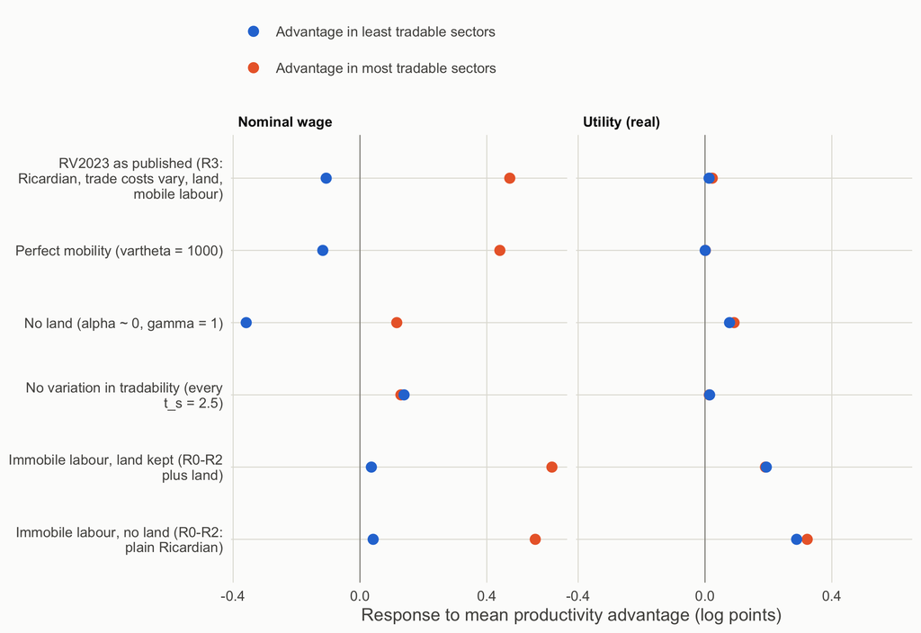

Figure 4: The Rice and Venables engine with switches (5 runs each, 300 places, 50 sectors). How a place’s nominal wage and its workers’ utility respond to Ricardian advantage in the most tradable third of sectors and in the least tradable third.

**What the benchmarks show.**

- **The nominal-wage result (C9) needs two things.** Tradability has to vary across sectors: with equal trade costs both responses are about 0.13. And labour has to be mobile: with immobile labour a non-tradable advantage no longer lowers wages (0.04).
- **Land isn’t essential to the sign.** Without land, local non-traded goods prices and imperfect mobility do the same job.
- **Real income responds equally to both kinds of advantage when labour is immobile.** With mobile labour, utility barely moves at all.

**Dornbusch–Fischer–Samuelson** (`08_ricardian_benchmarks.R`). This covers Venables’s experiments between two countries.

- **Import competition** in the home country’s best exports lowers its relative wage 7.9%. It also *raises* the share of non-traded goods from 30% to 43%.
- **So the shift to non-tradables after import competition is already Ricardian.** What Ricardo doesn’t give is the persistence: reverse the shock and DFS returns exactly to where it started.
- **The Rice and Venables engine with mild agglomeration** behaves the same way: a sector cut by 20% in its main place comes back in full when the cut is reversed.
- **Stronger agglomeration** (elasticity 0.04 or more) creates corners the solver can’t handle. Lock-in is shown in Model A.

## 4. The UK evidence

Table 7: UK replication of Rice and Venables (2023) section 4: area mean hourly earnings, 2015-2019, 2015 prices

| Sample | Outcome | Coefficient | t | R² | Paper coefficient | Paper R² |
| --- | --- | --- | --- | --- | --- | --- |
| All | Mean hourly earnings | 2.68 | 10.1 | 0.73 | 2.72 | 0.74 |
| All | Sector differential | 0.94 | 13.8 | 0.82 | 0.96 | 0.82 |
| All | Area differential | 1.74 | 7.8 | 0.58 | 1.76 | 0.59 |
| Excluding London | Mean hourly earnings | 1.88 | 11.6 | 0.52 | 1.91 | 0.54 |
| Excluding London | Sector differential | 0.94 | 17.4 | 0.72 | 0.97 | 0.71 |
| Excluding London | Area differential | 0.94 | 6.8 | 0.26 | 0.94 | 0.28 |

**The replication matches the paper closely.**

- **Correlations:** sparsity bias and area earnings correlate 0.857 (paper 0.86), and sector sparsity and sector earnings 0.46 (paper 0.46).
- **Variance:** sector mix explains 11% of the variance in area earnings and the area differential 53% (paper 11% and 52%).
- **Rankings:** the most and least sparse sectors, and the highest and lowest areas, are the paper’s.
- **The one difference:** sparsity bias is lower on average (mean 0.95 against 0.96), but with a similar spread.
- **Sample:** 251 sectors against the paper’s 259.

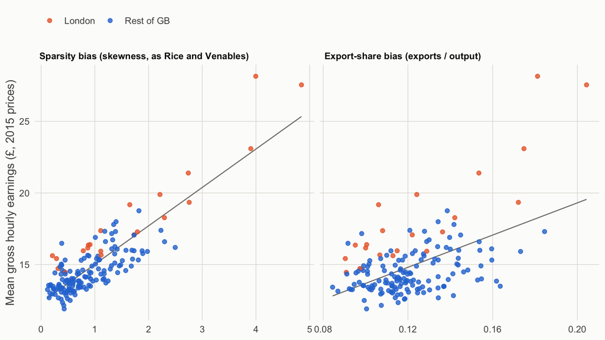

Figure 5: UK, 163 ITL3 areas: mean hourly earnings against sparsity bias (left) and against an export-share version built from the 2019 input-output tables (right)

**The tests the paper doesn’t run** (step 8 of the plan):

- **Measured tradability.** Exports as a share of output by product, from the 2019 input-output tables, correlate only 0.34 with sector sparsity.
  - An area’s export-share bias explains less of earnings (R² 0.27).
  - It adds nothing when entered with sparsity bias (coefficient -4.72, t = -0.8).
  - A caveat: exports measure trade with other countries. Rice and Venables’s tradability also covers trade between GB places, which the input-output tables don’t record. That gap is between the two versions of the argument.
- **London.** Sector sparsity computed without London’s areas correlates 0.83 with the original, and R² falls from 0.73 to 0.59. The result holds, but London’s concentration of high-wage sectors carries a good part of it.
- **Other measures.** The location-quotient and standard-deviation versions behave as in the paper’s Appendix 3. The Krugman specialisation index adds a little.

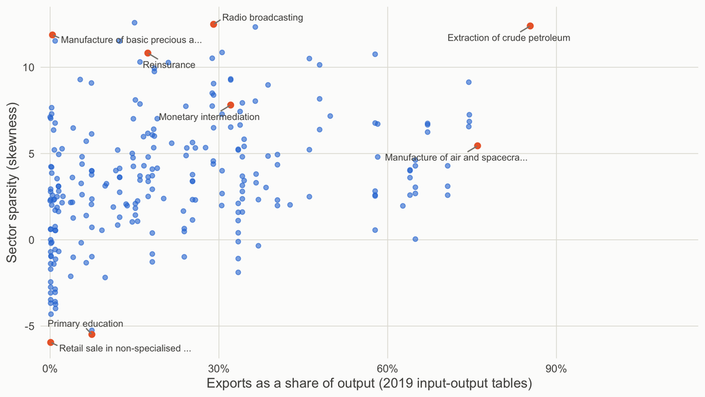

Figure 6: UK sectors: sparsity (skewness of location across ITL3 areas) against the share of output exported. Labelled: a few of the most and least sparse sectors.

So the UK result is real and robust. But it says high-wage places host geographically concentrated sectors. It doesn’t show that tradability, as opposed to agglomeration, sorting or the location of head offices, is what links the two. The 1971–1991 test (C12) isn’t rebuilt here.

## 5. How far can costs fall? (C8)

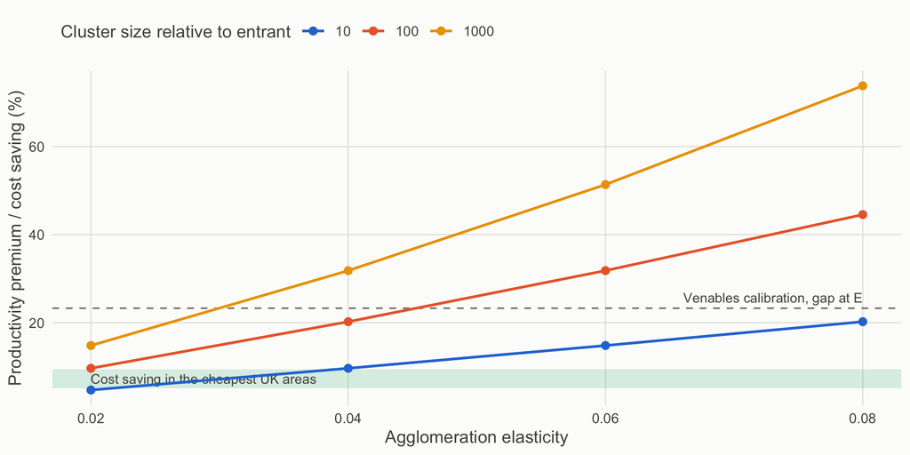

Figure 7: The cost advantage of the cheapest UK areas (band: bottom-quartile ITL3 areas, labour share 50-90%, property share 5-10%) against the productivity premium an established cluster has over a lone entrant, for a range of agglomeration elasticities and cluster sizes. Dashed line: the premium in Venables’s own calibration at E.

**How much cheaper lagging places are.** Bottom-quartile areas pay 8.4% less than average for the same jobs: this is the area differential, with sector mix removed. With property costs added (using Rice and Venables’s rent–earnings elasticity), a firm moving there cuts unit costs by 5.1–9.4%.

**Whether that’s enough depends on the cluster.**

- It’s enough against premiums up to about 9%. That means an elasticity of 0.02 with a cluster up to 100 times the entrant’s scale, or 0.04 with a cluster about 10 times its scale.
- It isn’t against large ones, nor against the 23% gap in Venables’s own calibration.
- So “too small to have leverage” is a claim about how strong agglomeration is, not a general property of regions.

**In Model A the lever isn’t local land at all.** A lone tradable firm in a type-N city faces the national non-tradable wage, so local costs can’t fall below it.

## 6. The claims, one by one

Table 8: Every claim against both benchmarks. Narrow = labour immobile between trading units; broad = adds mobile labour and land within a country. Categories: a = already Ricardo; b = standard extension; c = needs increasing returns with coordination failure.

| Claim | Versions | Narrow | Broad | Needs increasing returns | Category | Evidence |
| --- | --- | --- | --- | --- | --- | --- |
| C1 Each place specialises in tradables or non-tradables | V2020 | no | no | yes | c: needs increasing returns (the split itself is Ricardian) | In DFS the tradable/non-tradable split is endogenous (29.8% of goods non-traded) but every country makes both. In Model A without agglomeration cities are indifferent about what they make. |
| C2 A range of equilibria; history decides how many places are tradable | V2020 | no | no | yes | c: increasing returns with coordination failure (Graham 1923, Ethier 1982) | Model A: the set runs from 28.9% to 50.0% of cities; with no agglomeration it collapses to one point. DFS and the RV2023 engine (agglomeration up to 0.025) have one equilibrium. |
| C3 Places that lose tradables get non-tradable jobs, not new tradables, and stay that way | V2020, policy | partly | partly | yes | a for the shift to non-tradables; c for its persistence | In DFS an import shock also raises the non-traded share (29.8% to 43.1%) but through a 7.9% fall in the relative wage, and it reverses exactly. In Model A no lost tradable city is replaced while the e… |
| C4 The loss hurts every non-tradable place and booms the remaining tradable ones; the rent share rises | V2020 | n/a | partly | for persistence | b: dependent-economy price channel plus Rosen-Roback; c for persistence | Model A, X to 45%: wage in type-N cities -3.2%, their population -7.1%, their rents -13.7%, type-T wage +1.1%, rent share +0.01 points. The channel (a national price for non-tradables) is the Salter-S… |
| C5 A boom in some tradables knocks out other tradable places (Dutch disease) | V2020 | yes | yes | for persistence | b: Dutch disease (Corden and Neary 1982); c for the lock-in | Model A with two tradable sectors: old-sector cities start dropping into non-tradables when the new sector’s price is 9.0% higher; beyond about +12% the rest convert to the new sector instead. If both… |
| C6 Too few tradable places lowers aggregate real income | V2020 | no | no | yes, and more | c, and only if agglomeration runs out at the margin | With the papers’ own linear agglomeration, real income is 1.45% HIGHER at the low edge of the set. It is 1.21% lower only when agglomeration is used up beyond the size at X. |
| C7 Fiscal contraction shrinks non-tradable places and booms tradable ones, in two regimes | V2020 | partly | partly | for the regimes | b: real depreciation (Salter-Swan; DFS transfer problem); c for the two regimes | Model A, paper’s financing: type-N cities start switching to tradables at G = -13.5; with a balanced budget none switch by G = -25. DFS: a transfer abroad lowers the relative wage 1.8%, with no regime… |
| C8 Inside a country, absolute advantage rules; immobile factors are too small a cost share to restore competitiveness | V2020, RV2023 | premise | premise | no | a: Ricardo, “On Foreign Trade” (capital moves between provinces); the size claim is conditional | UK bottom-quartile areas pay 8.4% less for the same jobs; with property costs, unit costs are 5.1-9.4% lower. Cluster premiums: 4.7-20.2% (elasticity 0.02-0.04, size ratio 10-100). Model A’s own gap a… |
| C9 An advantage in tradables raises local nominal wages; one in non-tradables can lower them | RV2023, policy | half | yes | no | b: Balassa-Samuelson inside a Rosen-Roback spatial equilibrium | RV2023 engine (R3): log wage on tradable advantage 0.47, on non-tradable advantage -0.11. Narrow benchmark (immobile labour): 0.55 and 0.04, so no sign reversal. Equal trade costs: 0.13 and 0.14. |
| C9r Places with tradable jobs are better off in real terms | policy | no | no | yes (or immobile people) | false in both benchmarks; needs increasing returns or immobile people | Narrow benchmark: real income responds about equally to advantage in tradables (0.32) and non-tradables (0.29). Broad benchmark: utility barely moves with either (0.02, 0.01) because mobility equalise… |
| C10 Measured (revenue) productivity can diverge from physical productivity | RV2023 | no | yes | no | b: revenue versus physical productivity (Hsieh and Klenow 2009) in spatial equilibrium | Correlation of place wage (revenue productivity) with physical productivity: 0.87 in the narrow benchmark, 0.81 in R3, 0.11 in R3 without land. |
| C11 Sparsity bias accounts for about 75% of ITL3 earnings variation, two-thirds through the area effect | RV2023, policy | n/a | n/a | n/a | replicated, but it does not identify tradability | Rebuilt: adjusted R2 0.73, area differential 65.0% of the effect. But sector sparsity correlates only 0.34 with export shares, and export-share bias adds nothing beside sparsity (t = -0.8). Computing … |
| C12 Places that lost sparsity bias in 1971-91 lost relative earnings | RV2023 | n/a | n/a | n/a | not tested here | Needs the Census of Employment 1971-91 and New Earnings Survey county tables: not rebuilt in this round. |
| C13 Attracting non-tradable jobs crowds out tradables and locks places in | V2020, RV2023, policy | partly | partly | for the lock-in | b: Dutch disease from public spending; c for the lock-in | Model A: raising public spending on non-tradables (paper’s financing) starts pushing tradable cities into non-tradables at G = +11.0; by G = +25 the tradable share falls from 40% to 26.7%. |
| C14 The gains go to landowners in booming places | V2020 | n/a | yes | no | a/b: Ricardo’s own theory of rent; Rosen-Roback | Model A import shock: rent share +0.01 percentage points; rents in type-N cities -13.7%. Workers’ utility changes by +0.51%. |

## 7. Still open

- **C12 (the 1970s and 1980s).** This needs the Census of Employment county tables (1971, 1981, 1991) and New Earnings Survey Table 110. It’s not rebuilt.
- **Lock-in in the many-place model.** It needs a solver that can handle sectors vanishing from places. The current one converges only for weak agglomeration, where there is no lock-in.
- **Model B’s B and N rents.** This discrepancy with the paper’s Figure 6 is unexplained.
- **Table 1.** It’s only partly reproduced. Local rather than national rent rebates might close the gap, but that variant doesn’t converge yet.
- **Trade between GB places by sector.** Measures that capture it (for example from ONS subnational trade estimates) would test Rice and Venables’s version of tradability directly, rather than through exports.
- **Published versions.** Check them for the agglomeration typos and the other items in plan section 2.4.

*All code is in `code/tradeable_jobs/`. `00_run_all.R` rebuilds everything from downloads to this page.*